# Ecosystem Dynamics Lab 6

## Goals:

- Describe and apply a numerical approach to simulating both space and time using differential equations
- Conceptualize how plankton concentrations are sensitive to the light environment
- Apply the concept of light extinction and Beer’s Law to an ecosystem model
- Modify our existing vertical lake model for a new application (ocean carbon burial).

## Part 1: Space and time models

**Question 1:**

Provide an example model application when you would potentially need the following dimensions in ecosystem modeling:

**Answer 1:**

1. 0-D: A zero dimensional model is one that only operates in time, like a population model such as the NPZD model from lab 5.
2. 1-D: A 1-D model operates in one spatial dimension, such as a population model operating over a lake depth profile.
3. 2-D: A 2-D model operates over two spatial dimensions, such as a population model with depth profile and longitudinal profile of a stream
4. 3-D: A 3-D model operates of three dimensions, such as population model over Depth, longitudinal, and lateral profiles.

**Question 2:**

Describe the concept of flux divergence (see text).

**Answer 2:**

The concept of flux divergence accounts for the changes in fluxes with position within a constrained volume.

**Question 3:**

What is the difference between advection and diffusion?

**Answer 3:** Advection is a process which characterizes the motion of particles by a velocity, which often is a result of an acitve external influence. this force is assumed to largely be applied to all particles within a specified volume, resulting in uniform velocity responses according to particle mass.

Advection Flux = Velocity * Concentration

Dispersive/Diffusive fluxes are reflective of largely random motion of particles that are more passively spreading through a volume. This can be impacted by concentration gradients and equilibrium, with the former resulting in fluxes while the later does not.

Dispersion Flux = dispersion coefficent (D, Length^2 s-1) * concentration gradient.

Dispersion coefficent units reflect how fast the exchange is or how mobile the particle is.

**Question 4:**

Use the code that we covered in class to simulate the lake phytoplankton population for three years using 3 boxes instead of 48 boxes in the vertical dimension. How is your answer sensitive to the number of boxes that you use? (think about how the idea of the number of vertical boxes compares to the idea of time steps when solving differential equations)

**Answer 4:**

The number of boxes we use in the simulation relates to the resolution of the plots and identification of peaks in the total population counts. The larger bins mean an inclusion of more spread in each bin, and so the average of these larger bins are erasing the fine detail that is seen when the bin numbers are increased.

Spatial distribution with 3 bins

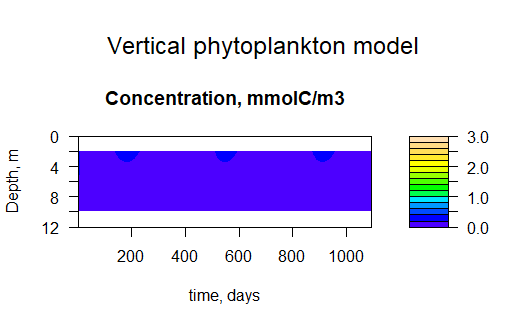

Spatial distribution with 48 bins

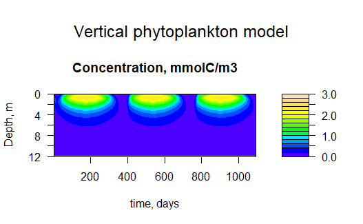

Population with 3 bins

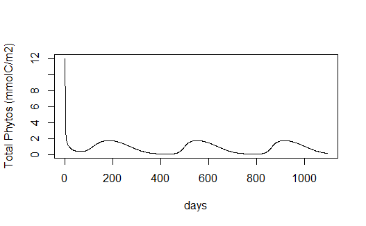

Population with 48 bins

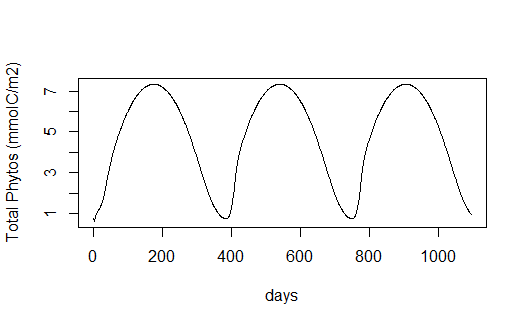

**Question 5:**

To control water quality, the amount of sediment coming into the lake has been reduced. Decreasing the sediment increases the light penetration, which decreases the light extinction coefficient from 0.9 to 0.1. Using your model, plot and describe how this alters the phytoplankton in the water column. Describe the reasons for the model behavior. **Be sure to use 48 vertical boxes**

**Answer 5:**

Decreasing the sediment and obstruction of light to deeper parts of the lake means that the phytoplankton concentrations at deeper depths increases. It also means that there is a more pronounced change in concentrations across the seasons, especially at mid depths. In the shoulder seasons, the concentrations at mid depth (4-8 m) see changes from high to low concentrations that were not seen in early models with lower light levels at these depths.

With a light extinction coefficient of 0.9

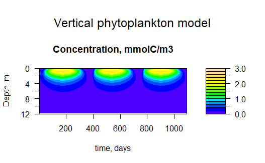

With a light extinction coefficient of 0.1

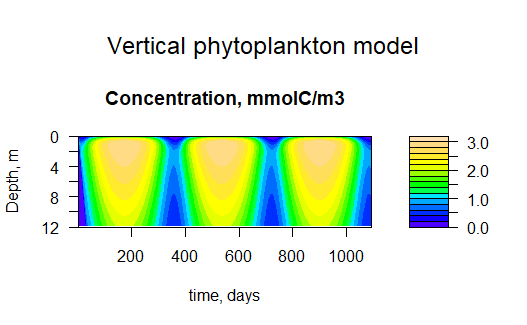

## Part 2: Ocean carbon burial

**Question 6:**

You can use the phytoplankton code as a guide for solving this question. Importantly, you will be simplifying the existing code. The question follows Question 6.7.3 in S&H.

The biological pump in the ocean is a component of the ocean carbon sink. The biological pump depends on primary production in the upper ocean sinking and escaping mineralization. If it is mineralized, then the CO2 returns to the atmosphere, thus not resulting in the net removal of CO2 from the atmosphere. We are interested in how the rate of dead organic matter sinking influences the vertical distribution of dead organic matter in the ocean.

The ocean has a euphotic zone and an aphotic zone. The euphotic zone has light and is where photosynthesis occurs (the depth of this zone is not relevant to this problem). The aphotic zone has no light, so only mineralization occurs. It is 400 m thick (i.e., 400 m deep).

Implement a numerical solution of dead organic matter sinking through the aphotic part of an oceanic water column. Dead organic matter is raining down from the productive euphotic zone. As it sinks through the water column, it is being degraded through mineralization. In building your model, assume that:

- The dead organic matter had a constant sinking velocity of (parameter u) of 50 m day-1. The sinking of the dead organic matter is an advective process.
- Model the degradation of dead organic matter as a first-order decay process, with a degradation rate (k) of 0.2 day-1.
- The flux of dead organic matter from the euphotic zone, i.e. the upper boundary for our model, is prescribed as 100 mmol C m-2 day-1. At the lower end of the water column, material leaves the water column to settle on the bottom.
- There is no diffusive mixing.
- Remember how you can add a second list to the output that is returned by your differential equation model function (see the PAR and CHL example in the NPZD model). Add the advective flux for the only last layer as an extra output. This is the carbon burial rate.

Run the model for a sufficiently long time so that the concentrations of dead organic matter stop changing over time.

Provide the code and solve your model.

**Answer 6:**

```r
deadOM_depth_model <- function(t, state, parms){

  #unpack states
  #note that PHYTOS is a vector where each cell is a different depth
  DEADOM <- state

  #Unpack parameters
  u <- parms[1]
  k <- parms[2]

  #Boundary conditions
  DeadOM_flux_top <- parms[3]

  #Physical description
  depth <- parms[4]
  numboxes <- parms[5]
  area <- parms[6]

  delx <- depth/numboxes

  # Advection calculation
  advection <- -u * (diff(DeadOM_flux_top)/delx)

  advection_flux <- c(DeadOM_flux_top, u * DEADOM) * area
  advection <- -(1/area) * (diff(advection_flux)/delx)


  # Decay calculation
  decay <- -k * DEADOM

  # Net change for each box (this a vector)
  dDEADOM_dt <- advection + decay

  burial_rate <- advection_flux[length(advection_flux)]

  return(list(dDEADOM_dt, burial_rate = burial_rate))

}
  #Parameters
#Currency = mmolC/m3
#Time scale = day
parms <- c(
  #Parameters
  50, # u: meters/day, Dead OM sinking rate
  .2, # k: day-1, degradation of Dead OM

  #Boundary conditions
  100, # DeadOM_flux_top (BOUNDRY CONDITION): mmolC/m2/d  flux at the upper boundary (Dead OM input from outside the aphotic zone)

  #Physical descriptions of the Aphotic Zone
  400, #Azone_depth: depth of Aphotic zone (m)
  60, #num of boxes.
  1) #area m2

numboxes <- parms[5]
#First set all layers equal to zero
yini <- rep(0, numboxes)

#Then initialize the layers where the OM is starting
yini[1] <- 0

library(deSolve)
#Use DeSolve to integrate
simulation_time <- .05 * 365 #DAYS
dt <- 1
times <- seq(1, simulation_time, by = dt)

output <- ode(y = yini,
              times = times,
              func = deadOM_depth_model,
              parms = parms)
```

**Question 7:**

Plot the output of your model as a contour plot with time on the x-axis and depth on the y-axis. The color should be the organic matter concentration. You will use the contour plot code provided in class as the base for the plot.

**Answer 7:**

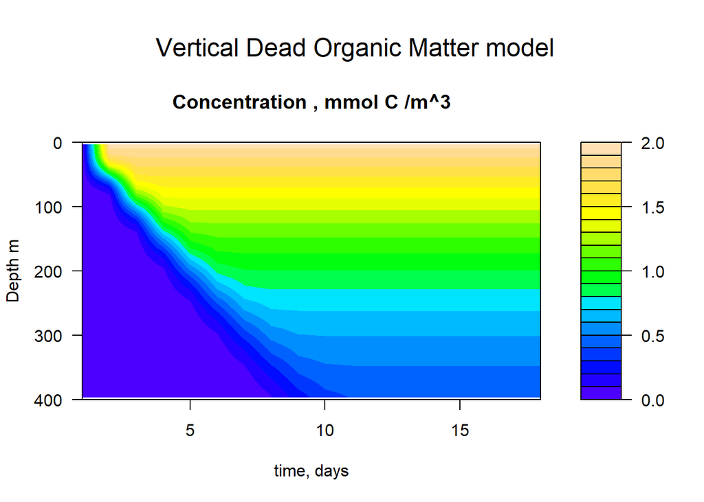

```r
Azone_depth <- parms[4]
numBoxes <- parms[5]
delx <- Azone_depth/numBoxes
output <- as.data.frame(output)

depths <- seq(from = delx/2, by = delx, length.out = numboxes)
names(output) <- c("time", depths)

DeadOM <- output[,2 :(numboxes + 1)]

par(oma = c(0,0,3,0))

col <- topo.colors

filled.contour(x = times, y = depths, z = as.matrix(DeadOM), color = col,
              ylim = c( Azone_depth,0), zlim  = range(c(DeadOM)), xlab = "time, days", ylab = "Depth m", main = "Concentration , mmol C /m^3"
)

mtext(outer = TRUE , side = 3, " Vertical Dead Organic Matter model", cex = 1.5)
```

## Part 3: Sensitivity of burial rates

How is the burial rate sensitive to the sinking rate? Reduce the sinking rate by half (from 50 m/s to 25 m/s) and simulate the burial rate.

**Question 8:**

Create a plot that includes the burial rate with a 50 m/s and 25 m/s sinking rate. Be sure to include a legend and axis labels. As an example of code for placing a legend: `legend("topright", c("50 m/s", "20 m/s"), col = c("black", "red"), lty = c("solid","solid"))`, Your plot should be a line graph with two lines.

**Answer 8:**

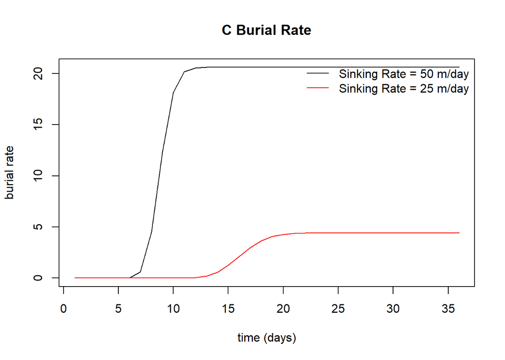

```r
deadOM_depth_model <- function(t, state, parms){

  #unpack states
  #note that PHYTOS is a vector where each cell is a different depth
  DEADOM <- state

  #Unpack parameters
  u <- parms[1]
  k <- parms[2]

  #Boundary conditions
  DeadOM_flux_top <- parms[3]

  #Physical description
  depth <- parms[4]
  numboxes <- parms[5]
  area <- parms[6]

  delx <- depth/numboxes

  # Advection calculation
  advection <- -u * (diff(DeadOM_flux_top)/delx)

  advection_flux <- c(DeadOM_flux_top, u * DEADOM) * area
  advection <- -(1/area) * (diff(advection_flux)/delx)


  # Decay calculation
  decay <- -k * DEADOM

  # Net change for each box (this a vector)
  dDEADOM_dt <- advection + decay

  burial_rate <- advection_flux[length(advection_flux)]

  return(list(dDEADOM_dt, burial_rate = burial_rate))

}
  #Parameters
#Currency = mmolC/m3
#Time scale = day
parms <- c(
  #Parameters
  50, # u: meters/day, Dead OM sinking rate
  .2, # k: day-1, degradation of Dead OM

  #Boundary conditions
  100, # DeadOM_flux_top (BOUNDRY CONDITION): mmolC/m2/d  flux at the upper boundary (Dead OM input from outside the aphotic zone)

  #Physical descriptions of the Aphotic Zone
  400, #Azone_depth: depth of Aphotic zone (m)
  60, #num of boxes.
  1) #area m2

numboxes <- parms[5]
#First set all layers equal to zero
yini <- rep(0, numboxes)

#Then initialize the layers where the OM is starting
yini[1] <- 0

library(deSolve)

#Use DeSolve to integrate
simulation_time <- .1 * 365 #DAYS
dt <- 1
times <- seq(1, simulation_time, by = dt)

output <- ode(y = yini,
              times = times,
              func = deadOM_depth_model,
              parms = parms)


output <- as.data.frame(output)

parms <- c(
  #Parameters
  25, # u: meters/day, Dead OM sinking rate
  .2, # k: day-1, degradation of Dead OM

  #Boundary conditions
  100, # DeadOM_flux_top (BOUNDRY CONDITION): mmolC/m2/d  flux at the upper boundary (Dead OM input from outside the aphotic zone)

  #Physical descriptions of the Aphotic Zone
  400, #Azone_depth: depth of Aphotic zone (m)
  60, #num of boxes.
  1) #area m2

numboxes <- parms[5]
#First set all layers equal to zero
yini <- rep(0, numboxes)

#Then initialize the layers where the OM is starting
yini[1] <- 0

library(deSolve)

#Use DeSolve to integrate
simulation_time <- .1 * 365 #DAYS
dt <- 1
times <- seq(1, simulation_time, by = dt)

output1 <- ode(y = yini,
              times = times,
              func = deadOM_depth_model,
              parms = parms)


output1 <- as.data.frame(output1)


plot(times, output$burial_rate, xlab = "time (days)", ylab = "burial rate", main = "C Burial Rate", type = "l")
points(times, output1$burial_rate, , type= "l", col = "red")

legend("topright", c("Sinking Rate = 50 m/day", "Sinking Rate = 25 m/day"), lty = c("solid"),
       col = c("black", "red"), bty = "n")
```

**Question 9:**

How does the burial rate respond to the sinking rate? Explain why it is sensitive (from a process/mechanistic perspective)

**Answer 9:**

The faster that dead OM can pass through the aphotic zone, the less time there is for mineralization to occur. As such, reducing the rate the dead OM sinks means it is the aphotic zone for longer, experiencing longer decay, leading to lower rates of accumulation of the fallen organic matter that passed through the zone without decaying.

**Question 10:**

“Some models are useful.” How was this modeling assignment useful?

**Answer 10:** This assignment made me consider the lose usage of carbon storage and rate terminology I have been using/exposed to early in my academic career. Building from the earlier content discussing productivity and other terms, this exercise helps me to better understand terms relevant to fate, such as accretion and burial. It also offers an example of the mechanisms relevant to these processes.